# Risk Factor Analysis

## Outcome Variable

**Outcome Variable:** wasted

## Predictor Variables

**Intervention Variable:** gagebrth

**Adjustment Set:**

- arm
- sex
- W_mage
- meducyrs
- feducyrs
- hhwealth_quart
- single
- brthmon
- W_parity
- delta_W_mage
- delta_meducyrs
- delta_feducyrs
- delta_hhwealth_quart
- delta_single
- delta_brthmon
- delta_W_parity

## Stratifying Variables

The analysis was stratified on these variable(s):

- agecat
- studyid
- country

## Data Summary

| agecat | studyid | country | gagebrth | wasted | n_cell | n |
| --- | --- | --- | --- | --- | --- | --- |
| Birth | ki1000108-CMC-V-BCS-2002 | INDIA | Full or late term | 0 | 46 | 87 |
| Birth | ki1000108-CMC-V-BCS-2002 | INDIA | Full or late term | 1 | 8 | 87 |
| Birth | ki1000108-CMC-V-BCS-2002 | INDIA | Preterm | 0 | 8 | 87 |
| Birth | ki1000108-CMC-V-BCS-2002 | INDIA | Preterm | 1 | 2 | 87 |
| Birth | ki1000108-CMC-V-BCS-2002 | INDIA | Early term | 0 | 20 | 87 |
| Birth | ki1000108-CMC-V-BCS-2002 | INDIA | Early term | 1 | 3 | 87 |
| Birth | ki1000108-IRC | INDIA | Full or late term | 0 | 164 | 328 |
| Birth | ki1000108-IRC | INDIA | Full or late term | 1 | 49 | 328 |
| Birth | ki1000108-IRC | INDIA | Preterm | 0 | 19 | 328 |
| Birth | ki1000108-IRC | INDIA | Preterm | 1 | 13 | 328 |
| Birth | ki1000108-IRC | INDIA | Early term | 0 | 58 | 328 |
| Birth | ki1000108-IRC | INDIA | Early term | 1 | 25 | 328 |
| Birth | ki1000109-EE | PAKISTAN | Full or late term | 0 | 0 | 1 |
| Birth | ki1000109-EE | PAKISTAN | Full or late term | 1 | 0 | 1 |
| Birth | ki1000109-EE | PAKISTAN | Preterm | 0 | 1 | 1 |
| Birth | ki1000109-EE | PAKISTAN | Preterm | 1 | 0 | 1 |
| Birth | ki1000109-EE | PAKISTAN | Early term | 0 | 0 | 1 |
| Birth | ki1000109-EE | PAKISTAN | Early term | 1 | 0 | 1 |
| Birth | ki1000304b-SAS-CompFeed | INDIA | Full or late term | 0 | 1 | 166 |
| Birth | ki1000304b-SAS-CompFeed | INDIA | Full or late term | 1 | 0 | 166 |
| Birth | ki1000304b-SAS-CompFeed | INDIA | Preterm | 0 | 141 | 166 |
| Birth | ki1000304b-SAS-CompFeed | INDIA | Preterm | 1 | 10 | 166 |
| Birth | ki1000304b-SAS-CompFeed | INDIA | Early term | 0 | 13 | 166 |
| Birth | ki1000304b-SAS-CompFeed | INDIA | Early term | 1 | 1 | 166 |
| Birth | ki1017093c-NIH-Crypto | BANGLADESH | Full or late term | 0 | 5 | 23 |
| Birth | ki1017093c-NIH-Crypto | BANGLADESH | Full or late term | 1 | 1 | 23 |
| Birth | ki1017093c-NIH-Crypto | BANGLADESH | Preterm | 0 | 2 | 23 |
| Birth | ki1017093c-NIH-Crypto | BANGLADESH | Preterm | 1 | 1 | 23 |
| Birth | ki1017093c-NIH-Crypto | BANGLADESH | Early term | 0 | 13 | 23 |
| Birth | ki1017093c-NIH-Crypto | BANGLADESH | Early term | 1 | 1 | 23 |

[output cut: 168 more lines]

The following strata were considered:

- agecat: 24 months, studyid: ki1000108-CMC-V-BCS-2002, country: INDIA
- agecat: 24 months, studyid: ki1000108-IRC, country: INDIA
- agecat: 24 months, studyid: ki1017093c-NIH-Crypto, country: BANGLADESH
- agecat: 24 months, studyid: ki1066203-TanzaniaChild2, country: TANZANIA, UNITED REPUBLIC OF
- agecat: 24 months, studyid: ki1101329-Keneba, country: GAMBIA
- agecat: 24 months, studyid: ki1119695-PROBIT, country: BELARUS
- agecat: 24 months, studyid: ki1135781-COHORTS, country: GUATEMALA
- agecat: 24 months, studyid: ki1135781-COHORTS, country: INDIA
- agecat: 24 months, studyid: ki1135781-COHORTS, country: PHILIPPINES
- agecat: 24 months, studyid: kiGH5241-JiVitA-3, country: BANGLADESH
- agecat: 6 months, studyid: ki1000108-CMC-V-BCS-2002, country: INDIA
- agecat: 6 months, studyid: ki1000108-IRC, country: INDIA
- agecat: 6 months, studyid: ki1000109-EE, country: PAKISTAN
- agecat: 6 months, studyid: ki1000304b-SAS-CompFeed, country: INDIA
- agecat: 6 months, studyid: ki1017093c-NIH-Crypto, country: BANGLADESH
- agecat: 6 months, studyid: ki1066203-TanzaniaChild2, country: TANZANIA, UNITED REPUBLIC OF
- agecat: 6 months, studyid: ki1101329-Keneba, country: GAMBIA
- agecat: 6 months, studyid: ki1119695-PROBIT, country: BELARUS
- agecat: 6 months, studyid: ki1135781-COHORTS, country: GUATEMALA
- agecat: 6 months, studyid: ki1135781-COHORTS, country: INDIA
- agecat: 6 months, studyid: ki1135781-COHORTS, country: PHILIPPINES
- agecat: 6 months, studyid: kiGH5241-JiVitA-3, country: BANGLADESH
- agecat: Birth, studyid: ki1000108-CMC-V-BCS-2002, country: INDIA
- agecat: Birth, studyid: ki1000108-IRC, country: INDIA
- agecat: Birth, studyid: ki1000109-EE, country: PAKISTAN
- agecat: Birth, studyid: ki1000304b-SAS-CompFeed, country: INDIA
- agecat: Birth, studyid: ki1017093c-NIH-Crypto, country: BANGLADESH
- agecat: Birth, studyid: ki1101329-Keneba, country: GAMBIA
- agecat: Birth, studyid: ki1119695-PROBIT, country: BELARUS
- agecat: Birth, studyid: ki1135781-COHORTS, country: GUATEMALA
- agecat: Birth, studyid: ki1135781-COHORTS, country: INDIA
- agecat: Birth, studyid: ki1135781-COHORTS, country: PHILIPPINES
- agecat: Birth, studyid: kiGH5241-JiVitA-3, country: BANGLADESH

### Dropped Strata

Some strata were dropped due to rare outcomes:

- agecat: Birth, studyid: ki1000108-CMC-V-BCS-2002, country: INDIA
- agecat: Birth, studyid: ki1000109-EE, country: PAKISTAN
- agecat: Birth, studyid: ki1000304b-SAS-CompFeed, country: INDIA
- agecat: Birth, studyid: ki1017093c-NIH-Crypto, country: BANGLADESH
- agecat: 6 months, studyid: ki1000109-EE, country: PAKISTAN
- agecat: 6 months, studyid: ki1017093c-NIH-Crypto, country: BANGLADESH
- agecat: 6 months, studyid: ki1135781-COHORTS, country: GUATEMALA
- agecat: 24 months, studyid: ki1000108-CMC-V-BCS-2002, country: INDIA
- agecat: 24 months, studyid: ki1017093c-NIH-Crypto, country: BANGLADESH
- agecat: 24 months, studyid: ki1066203-TanzaniaChild2, country: TANZANIA, UNITED REPUBLIC OF
- agecat: 24 months, studyid: ki1119695-PROBIT, country: BELARUS

## Methods Detail

We’re interested in the causal parameters $E[Y_a]$ for all values of $a \in \mathcal{A}$. These parameters represent the mean outcome if, possibly contrary to fact, we intervened to set all units to have $A=a$. Under the randomization and positivity assumptions, these are identified by the statistical parameters $\psi_a=E_W[E_{Y|A,W}(Y|A=a,W)]$. In addition, we’re interested in the mean of $Y$, $E[Y]$ under no intervention (the observed mean). We will estimate these parameters by using SuperLearner to fit the relevant likelihood factors – $E_{Y|A,W}(Y|A=a,W)$ and $p(A=a|W)$, and then updating our likelihood fit using a joint TMLE.

For unadjusted analyses ($W=\{\}$), initial likelihoods were estimated using Lrnr_glm to estimate the simple $E(Y|A)$ and Lrnr_mean to estimate $p(A)$. For adjusted analyses, a small library containing Lrnr_glmnet, Lrnr_xgboost, and Lrnr_mean was used.

Having estimated these parameters, we will then use the delta method to estimate relative risks and attributable risks relative to a prespecified baseline level of $A$.

# Results Detail

## Results Plots

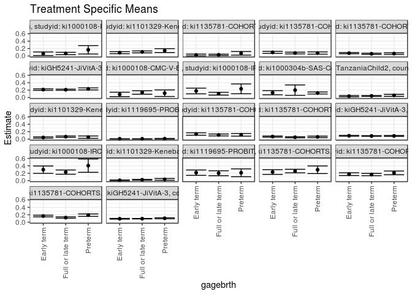

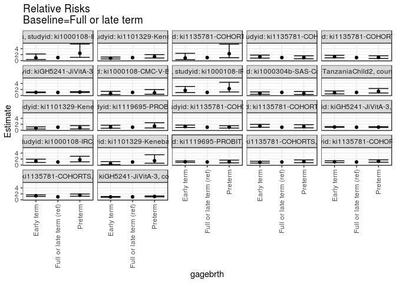

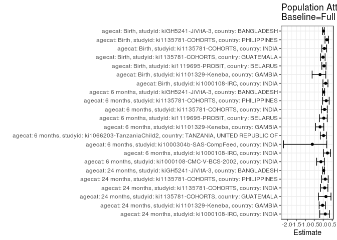

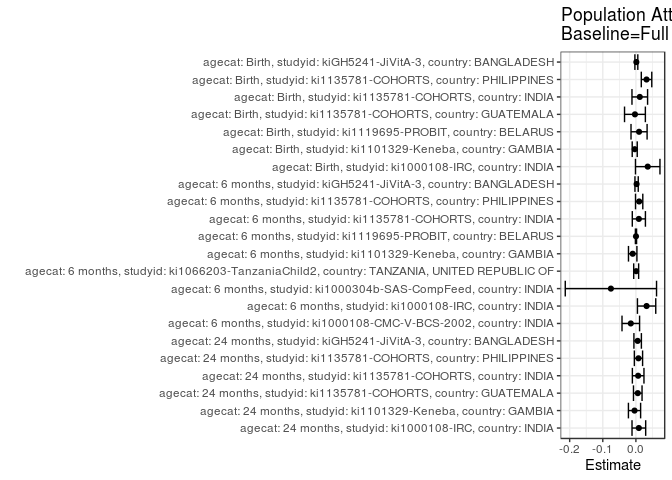

## Results Table

### Parameter: TSM

| agecat | studyid | country | intervention_level | baseline_level | estimate | ci_lower | ci_upper |
| --- | --- | --- | --- | --- | --- | --- | --- |
| Birth | ki1000108-IRC | INDIA | Full or late term | NA | 0.2295298 | 0.1724840 | 0.2865756 |
| Birth | ki1000108-IRC | INDIA | Preterm | NA | 0.4038769 | 0.2242721 | 0.5834817 |
| Birth | ki1000108-IRC | INDIA | Early term | NA | 0.2957080 | 0.1966450 | 0.3947710 |
| Birth | ki1101329-Keneba | GAMBIA | Full or late term | NA | 0.0235294 | 0.0121326 | 0.0349262 |
| Birth | ki1101329-Keneba | GAMBIA | Preterm | NA | 0.0338164 | 0.0091837 | 0.0584491 |
| Birth | ki1101329-Keneba | GAMBIA | Early term | NA | 0.0097276 | 0.0012397 | 0.0182156 |
| Birth | ki1119695-PROBIT | BELARUS | Full or late term | NA | 0.1993730 | 0.1332619 | 0.2654842 |
| Birth | ki1119695-PROBIT | BELARUS | Preterm | NA | 0.2120934 | 0.1067468 | 0.3174399 |
| Birth | ki1119695-PROBIT | BELARUS | Early term | NA | 0.2147750 | 0.1426821 | 0.2868679 |
| Birth | ki1135781-COHORTS | GUATEMALA | Full or late term | NA | 0.2580969 | 0.2104313 | 0.3057626 |
| Birth | ki1135781-COHORTS | GUATEMALA | Preterm | NA | 0.2932818 | 0.1906130 | 0.3959506 |
| Birth | ki1135781-COHORTS | GUATEMALA | Early term | NA | 0.2317800 | 0.1679561 | 0.2956039 |
| Birth | ki1135781-COHORTS | INDIA | Full or late term | NA | 0.1648417 | 0.1338788 | 0.1958045 |
| Birth | ki1135781-COHORTS | INDIA | Preterm | NA | 0.2085932 | 0.1582897 | 0.2588967 |
| Birth | ki1135781-COHORTS | INDIA | Early term | NA | 0.1755193 | 0.1388431 | 0.2121955 |
| Birth | ki1135781-COHORTS | PHILIPPINES | Full or late term | NA | 0.1233797 | 0.1043500 | 0.1424094 |
| Birth | ki1135781-COHORTS | PHILIPPINES | Preterm | NA | 0.1899269 | 0.1577127 | 0.2221412 |
| Birth | ki1135781-COHORTS | PHILIPPINES | Early term | NA | 0.1664612 | 0.1448655 | 0.1880569 |
| Birth | kiGH5241-JiVitA-3 | BANGLADESH | Full or late term | NA | 0.0947303 | 0.0879228 | 0.1015379 |
| Birth | kiGH5241-JiVitA-3 | BANGLADESH | Preterm | NA | 0.1056115 | 0.0926748 | 0.1185482 |
| Birth | kiGH5241-JiVitA-3 | BANGLADESH | Early term | NA | 0.0920879 | 0.0824818 | 0.1016940 |
| 6 months | ki1000108-CMC-V-BCS-2002 | INDIA | Full or late term | NA | 0.1367925 | 0.0904694 | 0.1831155 |
| 6 months | ki1000108-CMC-V-BCS-2002 | INDIA | Preterm | NA | 0.1176471 | 0.0290941 | 0.2062000 |
| 6 months | ki1000108-CMC-V-BCS-2002 | INDIA | Early term | NA | 0.0843373 | 0.0244665 | 0.1442082 |
| 6 months | ki1000108-IRC | INDIA | Full or late term | NA | 0.1042825 | 0.0662473 | 0.1423177 |
| 6 months | ki1000108-IRC | INDIA | Preterm | NA | 0.2347922 | 0.1028204 | 0.3667639 |
| 6 months | ki1000108-IRC | INDIA | Early term | NA | 0.1766863 | 0.0996582 | 0.2537144 |
| 6 months | ki1000304b-SAS-CompFeed | INDIA | Full or late term | NA | 0.2000000 | 0.0598640 | 0.3401360 |
| 6 months | ki1000304b-SAS-CompFeed | INDIA | Preterm | NA | 0.1225166 | 0.0952376 | 0.1497956 |
| 6 months | ki1000304b-SAS-CompFeed | INDIA | Early term | NA | 0.1304348 | 0.0742562 | 0.1866133 |
| 6 months | ki1066203-TanzaniaChild2 | TANZANIA, UNITED REPUBLIC OF | Full or late term | NA | 0.0438579 | 0.0320865 | 0.0556294 |
| 6 months | ki1066203-TanzaniaChild2 | TANZANIA, UNITED REPUBLIC OF | Preterm | NA | 0.0596430 | 0.0320956 | 0.0871903 |
| 6 months | ki1066203-TanzaniaChild2 | TANZANIA, UNITED REPUBLIC OF | Early term | NA | 0.0372172 | 0.0195592 | 0.0548752 |
| 6 months | ki1101329-Keneba | GAMBIA | Full or late term | NA | 0.0649713 | 0.0460424 | 0.0839002 |
| 6 months | ki1101329-Keneba | GAMBIA | Preterm | NA | 0.0526667 | 0.0217952 | 0.0835382 |
| 6 months | ki1101329-Keneba | GAMBIA | Early term | NA | 0.0430708 | 0.0253795 | 0.0607620 |
| 6 months | ki1119695-PROBIT | BELARUS | Full or late term | NA | 0.0079950 | 0.0052987 | 0.0106913 |
| 6 months | ki1119695-PROBIT | BELARUS | Preterm | NA | 0.0108893 | 0.0041768 | 0.0176017 |
| 6 months | ki1119695-PROBIT | BELARUS | Early term | NA | 0.0083322 | 0.0061258 | 0.0105385 |
| 6 months | ki1135781-COHORTS | INDIA | Full or late term | NA | 0.1122317 | 0.0862474 | 0.1382160 |
| 6 months | ki1135781-COHORTS | INDIA | Preterm | NA | 0.1146921 | 0.0794271 | 0.1499571 |
| 6 months | ki1135781-COHORTS | INDIA | Early term | NA | 0.1375621 | 0.1058071 | 0.1693171 |
| 6 months | ki1135781-COHORTS | PHILIPPINES | Full or late term | NA | 0.0493576 | 0.0360778 | 0.0626374 |
| 6 months | ki1135781-COHORTS | PHILIPPINES | Preterm | NA | 0.0595705 | 0.0401593 | 0.0789818 |
| 6 months | ki1135781-COHORTS | PHILIPPINES | Early term | NA | 0.0684868 | 0.0535094 | 0.0834643 |
| 6 months | kiGH5241-JiVitA-3 | BANGLADESH | Full or late term | NA | 0.0839695 | 0.0767202 | 0.0912187 |
| 6 months | kiGH5241-JiVitA-3 | BANGLADESH | Preterm | NA | 0.0862422 | 0.0744052 | 0.0980791 |
| 6 months | kiGH5241-JiVitA-3 | BANGLADESH | Early term | NA | 0.0895094 | 0.0787941 | 0.1002247 |
| 24 months | ki1000108-IRC | INDIA | Full or late term | NA | 0.0680000 | 0.0367537 | 0.0992463 |
| 24 months | ki1000108-IRC | INDIA | Preterm | NA | 0.1666667 | 0.0538133 | 0.2795201 |
| 24 months | ki1000108-IRC | INDIA | Early term | NA | 0.0612245 | 0.0136980 | 0.1087510 |
| 24 months | ki1101329-Keneba | GAMBIA | Full or late term | NA | 0.1104491 | 0.0843833 | 0.1365150 |
| 24 months | ki1101329-Keneba | GAMBIA | Preterm | NA | 0.1451867 | 0.0932111 | 0.1971624 |
| 24 months | ki1101329-Keneba | GAMBIA | Early term | NA | 0.0897110 | 0.0628961 | 0.1165259 |
| 24 months | ki1135781-COHORTS | GUATEMALA | Full or late term | NA | 0.0318302 | 0.0140966 | 0.0495639 |
| 24 months | ki1135781-COHORTS | GUATEMALA | Preterm | NA | 0.0733945 | 0.0244008 | 0.1223881 |
| 24 months | ki1135781-COHORTS | GUATEMALA | Early term | NA | 0.0276243 | 0.0037298 | 0.0515188 |
| 24 months | ki1135781-COHORTS | INDIA | Full or late term | NA | 0.0802047 | 0.0574231 | 0.1029862 |
| 24 months | ki1135781-COHORTS | INDIA | Preterm | NA | 0.0802916 | 0.0496016 | 0.1109816 |
| 24 months | ki1135781-COHORTS | INDIA | Early term | NA | 0.0988797 | 0.0709387 | 0.1268206 |
| 24 months | ki1135781-COHORTS | PHILIPPINES | Full or late term | NA | 0.0605823 | 0.0452413 | 0.0759233 |
| 24 months | ki1135781-COHORTS | PHILIPPINES | Preterm | NA | 0.0647750 | 0.0434424 | 0.0861076 |
| 24 months | ki1135781-COHORTS | PHILIPPINES | Early term | NA | 0.0772773 | 0.0604678 | 0.0940868 |
| 24 months | kiGH5241-JiVitA-3 | BANGLADESH | Full or late term | NA | 0.2106231 | 0.1941357 | 0.2271106 |
| 24 months | kiGH5241-JiVitA-3 | BANGLADESH | Preterm | NA | 0.2325291 | 0.2051799 | 0.2598784 |
| 24 months | kiGH5241-JiVitA-3 | BANGLADESH | Early term | NA | 0.2144794 | 0.1938733 | 0.2350855 |

### Parameter: E(Y)

| agecat | studyid | country | intervention_level | baseline_level | estimate | ci_lower | ci_upper |
| --- | --- | --- | --- | --- | --- | --- | --- |
| Birth | ki1000108-IRC | INDIA | NA | NA | 0.2652439 | 0.2173954 | 0.3130924 |
| Birth | ki1101329-Keneba | GAMBIA | NA | NA | 0.0199857 | 0.0126548 | 0.0273167 |
| Birth | ki1119695-PROBIT | BELARUS | NA | NA | 0.2089120 | 0.1435514 | 0.2742726 |
| Birth | ki1135781-COHORTS | GUATEMALA | NA | NA | 0.2552448 | 0.2194833 | 0.2910062 |
| Birth | ki1135781-COHORTS | INDIA | NA | NA | 0.1765663 | 0.1552399 | 0.1978927 |
| Birth | ki1135781-COHORTS | PHILIPPINES | NA | NA | 0.1555324 | 0.1422803 | 0.1687844 |
| Birth | kiGH5241-JiVitA-3 | BANGLADESH | NA | NA | 0.0961020 | 0.0908277 | 0.1013762 |
| 6 months | ki1000108-CMC-V-BCS-2002 | INDIA | NA | NA | 0.1213873 | 0.0869266 | 0.1558480 |
| 6 months | ki1000108-IRC | INDIA | NA | NA | 0.1365979 | 0.1023826 | 0.1708133 |
| 6 months | ki1000304b-SAS-CompFeed | INDIA | NA | NA | 0.1245283 | 0.0993306 | 0.1497260 |
| 6 months | ki1066203-TanzaniaChild2 | TANZANIA, UNITED REPUBLIC OF | NA | NA | 0.0446898 | 0.0354016 | 0.0539780 |
| 6 months | ki1101329-Keneba | GAMBIA | NA | NA | 0.0553130 | 0.0432217 | 0.0674042 |
| 6 months | ki1119695-PROBIT | BELARUS | NA | NA | 0.0082503 | 0.0066012 | 0.0098994 |
| 6 months | ki1135781-COHORTS | INDIA | NA | NA | 0.1211890 | 0.1035235 | 0.1388545 |
| 6 months | ki1135781-COHORTS | PHILIPPINES | NA | NA | 0.0592179 | 0.0502884 | 0.0681474 |
| 6 months | kiGH5241-JiVitA-3 | BANGLADESH | NA | NA | 0.0860879 | 0.0805805 | 0.0915953 |
| 24 months | ki1000108-IRC | INDIA | NA | NA | 0.0769231 | 0.0504429 | 0.1034032 |
| 24 months | ki1101329-Keneba | GAMBIA | NA | NA | 0.1063094 | 0.0885410 | 0.1240778 |
| 24 months | ki1135781-COHORTS | GUATEMALA | NA | NA | 0.0374813 | 0.0230560 | 0.0519065 |
| 24 months | ki1135781-COHORTS | INDIA | NA | NA | 0.0870570 | 0.0717143 | 0.1023997 |
| 24 months | ki1135781-COHORTS | PHILIPPINES | NA | NA | 0.0683690 | 0.0583283 | 0.0784097 |
| 24 months | kiGH5241-JiVitA-3 | BANGLADESH | NA | NA | 0.2159196 | 0.2043522 | 0.2274871 |

### Parameter: RR

| agecat | studyid | country | intervention_level | baseline_level | estimate | ci_lower | ci_upper |
| --- | --- | --- | --- | --- | --- | --- | --- |
| Birth | ki1000108-IRC | INDIA | Full or late term | Full or late term | 1.0000000 | 1.0000000 | 1.000000 |
| Birth | ki1000108-IRC | INDIA | Preterm | Full or late term | 1.7595838 | 1.0569245 | 2.929381 |
| Birth | ki1000108-IRC | INDIA | Early term | Full or late term | 1.2883207 | 0.8495101 | 1.953797 |
| Birth | ki1101329-Keneba | GAMBIA | Full or late term | Full or late term | 1.0000000 | 1.0000000 | 1.000000 |
| Birth | ki1101329-Keneba | GAMBIA | Preterm | Full or late term | 1.4371981 | 0.5992553 | 3.446842 |
| Birth | ki1101329-Keneba | GAMBIA | Early term | Full or late term | 0.4134241 | 0.1523972 | 1.121539 |
| Birth | ki1119695-PROBIT | BELARUS | Full or late term | Full or late term | 1.0000000 | 1.0000000 | 1.000000 |
| Birth | ki1119695-PROBIT | BELARUS | Preterm | Full or late term | 1.0638017 | 0.6924568 | 1.634288 |
| Birth | ki1119695-PROBIT | BELARUS | Early term | Full or late term | 1.0772521 | 0.8616829 | 1.346751 |
| Birth | ki1135781-COHORTS | GUATEMALA | Full or late term | Full or late term | 1.0000000 | 1.0000000 | 1.000000 |
| Birth | ki1135781-COHORTS | GUATEMALA | Preterm | Full or late term | 1.1363241 | 0.7648225 | 1.688277 |
| Birth | ki1135781-COHORTS | GUATEMALA | Early term | Full or late term | 0.8980345 | 0.6445809 | 1.251148 |
| Birth | ki1135781-COHORTS | INDIA | Full or late term | Full or late term | 1.0000000 | 1.0000000 | 1.000000 |
| Birth | ki1135781-COHORTS | INDIA | Preterm | Full or late term | 1.2654155 | 0.9323240 | 1.717511 |
| Birth | ki1135781-COHORTS | INDIA | Early term | Full or late term | 1.0647750 | 0.8036577 | 1.410732 |
| Birth | ki1135781-COHORTS | PHILIPPINES | Full or late term | Full or late term | 1.0000000 | 1.0000000 | 1.000000 |
| Birth | ki1135781-COHORTS | PHILIPPINES | Preterm | Full or late term | 1.5393695 | 1.2244063 | 1.935353 |
| Birth | ki1135781-COHORTS | PHILIPPINES | Early term | Full or late term | 1.3491781 | 1.1032206 | 1.649971 |
| Birth | kiGH5241-JiVitA-3 | BANGLADESH | Full or late term | Full or late term | 1.0000000 | 1.0000000 | 1.000000 |
| Birth | kiGH5241-JiVitA-3 | BANGLADESH | Preterm | Full or late term | 1.1148643 | 0.9682091 | 1.283734 |
| Birth | kiGH5241-JiVitA-3 | BANGLADESH | Early term | Full or late term | 0.9721061 | 0.8583622 | 1.100922 |
| 6 months | ki1000108-CMC-V-BCS-2002 | INDIA | Full or late term | Full or late term | 1.0000000 | 1.0000000 | 1.000000 |
| 6 months | ki1000108-CMC-V-BCS-2002 | INDIA | Preterm | Full or late term | 0.8600406 | 0.3767610 | 1.963234 |
| 6 months | ki1000108-CMC-V-BCS-2002 | INDIA | Early term | Full or late term | 0.6165351 | 0.2807839 | 1.353765 |
| 6 months | ki1000108-IRC | INDIA | Full or late term | Full or late term | 1.0000000 | 1.0000000 | 1.000000 |
| 6 months | ki1000108-IRC | INDIA | Preterm | Full or late term | 2.2515009 | 1.1514604 | 4.402458 |
| 6 months | ki1000108-IRC | INDIA | Early term | Full or late term | 1.6943040 | 0.9590783 | 2.993151 |
| 6 months | ki1000304b-SAS-CompFeed | INDIA | Full or late term | Full or late term | 1.0000000 | 1.0000000 | 1.000000 |
| 6 months | ki1000304b-SAS-CompFeed | INDIA | Preterm | Full or late term | 0.6125828 | 0.2912002 | 1.288659 |
| 6 months | ki1000304b-SAS-CompFeed | INDIA | Early term | Full or late term | 0.6521739 | 0.3675930 | 1.157070 |
| 6 months | ki1066203-TanzaniaChild2 | TANZANIA, UNITED REPUBLIC OF | Full or late term | Full or late term | 1.0000000 | 1.0000000 | 1.000000 |
| 6 months | ki1066203-TanzaniaChild2 | TANZANIA, UNITED REPUBLIC OF | Preterm | Full or late term | 1.3599121 | 0.7970574 | 2.320235 |
| 6 months | ki1066203-TanzaniaChild2 | TANZANIA, UNITED REPUBLIC OF | Early term | Full or late term | 0.8485848 | 0.4919320 | 1.463813 |
| 6 months | ki1101329-Keneba | GAMBIA | Full or late term | Full or late term | 1.0000000 | 1.0000000 | 1.000000 |
| 6 months | ki1101329-Keneba | GAMBIA | Preterm | Full or late term | 0.8106149 | 0.4211560 | 1.560221 |
| 6 months | ki1101329-Keneba | GAMBIA | Early term | Full or late term | 0.6629199 | 0.4005792 | 1.097068 |
| 6 months | ki1119695-PROBIT | BELARUS | Full or late term | Full or late term | 1.0000000 | 1.0000000 | 1.000000 |
| 6 months | ki1119695-PROBIT | BELARUS | Preterm | Full or late term | 1.3620122 | 0.7433311 | 2.495627 |
| 6 months | ki1119695-PROBIT | BELARUS | Early term | Full or late term | 1.0421730 | 0.6561487 | 1.655302 |
| 6 months | ki1135781-COHORTS | INDIA | Full or late term | Full or late term | 1.0000000 | 1.0000000 | 1.000000 |
| 6 months | ki1135781-COHORTS | INDIA | Preterm | Full or late term | 1.0219223 | 0.6953884 | 1.501787 |
| 6 months | ki1135781-COHORTS | INDIA | Early term | Full or late term | 1.2256969 | 0.8845790 | 1.698359 |
| 6 months | ki1135781-COHORTS | PHILIPPINES | Full or late term | Full or late term | 1.0000000 | 1.0000000 | 1.000000 |
| 6 months | ki1135781-COHORTS | PHILIPPINES | Preterm | Full or late term | 1.2069172 | 0.7911412 | 1.841200 |
| 6 months | ki1135781-COHORTS | PHILIPPINES | Early term | Full or late term | 1.3875641 | 0.9813593 | 1.961906 |
| 6 months | kiGH5241-JiVitA-3 | BANGLADESH | Full or late term | Full or late term | 1.0000000 | 1.0000000 | 1.000000 |
| 6 months | kiGH5241-JiVitA-3 | BANGLADESH | Preterm | Full or late term | 1.0270658 | 0.8784436 | 1.200833 |
| 6 months | kiGH5241-JiVitA-3 | BANGLADESH | Early term | Full or late term | 1.0659760 | 0.9208156 | 1.234020 |
| 24 months | ki1000108-IRC | INDIA | Full or late term | Full or late term | 1.0000000 | 1.0000000 | 1.000000 |
| 24 months | ki1000108-IRC | INDIA | Preterm | Full or late term | 2.4509804 | 1.0813122 | 5.555569 |
| 24 months | ki1000108-IRC | INDIA | Early term | Full or late term | 0.9003601 | 0.3653015 | 2.219121 |
| 24 months | ki1101329-Keneba | GAMBIA | Full or late term | Full or late term | 1.0000000 | 1.0000000 | 1.000000 |
| 24 months | ki1101329-Keneba | GAMBIA | Preterm | Full or late term | 1.3145123 | 0.8559923 | 2.018643 |
| 24 months | ki1101329-Keneba | GAMBIA | Early term | Full or late term | 0.8122382 | 0.5549740 | 1.188760 |
| 24 months | ki1135781-COHORTS | GUATEMALA | Full or late term | Full or late term | 1.0000000 | 1.0000000 | 1.000000 |
| 24 months | ki1135781-COHORTS | GUATEMALA | Preterm | Full or late term | 2.3058104 | 0.9665200 | 5.500933 |
| 24 months | ki1135781-COHORTS | GUATEMALA | Early term | Full or late term | 0.8678637 | 0.3101816 | 2.428214 |
| 24 months | ki1135781-COHORTS | INDIA | Full or late term | Full or late term | 1.0000000 | 1.0000000 | 1.000000 |
| 24 months | ki1135781-COHORTS | INDIA | Preterm | Full or late term | 1.0010840 | 0.6218665 | 1.611550 |
| 24 months | ki1135781-COHORTS | INDIA | Early term | Full or late term | 1.2328422 | 0.8265100 | 1.838937 |
| 24 months | ki1135781-COHORTS | PHILIPPINES | Full or late term | Full or late term | 1.0000000 | 1.0000000 | 1.000000 |
| 24 months | ki1135781-COHORTS | PHILIPPINES | Preterm | Full or late term | 1.0692068 | 0.7057831 | 1.619766 |
| 24 months | ki1135781-COHORTS | PHILIPPINES | Early term | Full or late term | 1.2755760 | 0.9134972 | 1.781170 |
| 24 months | kiGH5241-JiVitA-3 | BANGLADESH | Full or late term | Full or late term | 1.0000000 | 1.0000000 | 1.000000 |
| 24 months | kiGH5241-JiVitA-3 | BANGLADESH | Preterm | Full or late term | 1.1040057 | 0.9584108 | 1.271718 |
| 24 months | kiGH5241-JiVitA-3 | BANGLADESH | Early term | Full or late term | 1.0183089 | 0.8989018 | 1.153577 |

### Parameter: PAR

| agecat | studyid | country | intervention_level | baseline_level | estimate | ci_lower | ci_upper |
| --- | --- | --- | --- | --- | --- | --- | --- |
| Birth | ki1000108-IRC | INDIA | Full or late term | NA | 0.0357141 | -0.0012543 | 0.0726825 |
| Birth | ki1101329-Keneba | GAMBIA | Full or late term | NA | -0.0035437 | -0.0111295 | 0.0040421 |
| Birth | ki1119695-PROBIT | BELARUS | Full or late term | NA | 0.0095390 | -0.0147481 | 0.0338261 |
| Birth | ki1135781-COHORTS | GUATEMALA | Full or late term | NA | -0.0028522 | -0.0343145 | 0.0286102 |
| Birth | ki1135781-COHORTS | INDIA | Full or late term | NA | 0.0117246 | -0.0118489 | 0.0352982 |
| Birth | ki1135781-COHORTS | PHILIPPINES | Full or late term | NA | 0.0321527 | 0.0163222 | 0.0479831 |
| Birth | kiGH5241-JiVitA-3 | BANGLADESH | Full or late term | NA | 0.0013716 | -0.0030423 | 0.0057856 |
| 6 months | ki1000108-CMC-V-BCS-2002 | INDIA | Full or late term | NA | -0.0154052 | -0.0419343 | 0.0111240 |
| 6 months | ki1000108-IRC | INDIA | Full or late term | NA | 0.0323154 | 0.0046695 | 0.0599613 |
| 6 months | ki1000304b-SAS-CompFeed | INDIA | Full or late term | NA | -0.0754717 | -0.2132929 | 0.0623495 |
| 6 months | ki1066203-TanzaniaChild2 | TANZANIA, UNITED REPUBLIC OF | Full or late term | NA | 0.0008319 | -0.0066151 | 0.0082788 |
| 6 months | ki1101329-Keneba | GAMBIA | Full or late term | NA | -0.0096583 | -0.0223924 | 0.0030758 |
| 6 months | ki1119695-PROBIT | BELARUS | Full or late term | NA | 0.0002553 | -0.0015024 | 0.0020130 |
| 6 months | ki1135781-COHORTS | INDIA | Full or late term | NA | 0.0089573 | -0.0108640 | 0.0287786 |
| 6 months | ki1135781-COHORTS | PHILIPPINES | Full or late term | NA | 0.0098603 | -0.0011236 | 0.0208442 |
| 6 months | kiGH5241-JiVitA-3 | BANGLADESH | Full or late term | NA | 0.0021185 | -0.0028554 | 0.0070924 |
| 24 months | ki1000108-IRC | INDIA | Full or late term | NA | 0.0089231 | -0.0117124 | 0.0295586 |
| 24 months | ki1101329-Keneba | GAMBIA | Full or late term | NA | -0.0041397 | -0.0225492 | 0.0142698 |
| 24 months | ki1135781-COHORTS | GUATEMALA | Full or late term | NA | 0.0056510 | -0.0072744 | 0.0185765 |
| 24 months | ki1135781-COHORTS | INDIA | Full or late term | NA | 0.0068524 | -0.0106466 | 0.0243513 |
| 24 months | ki1135781-COHORTS | PHILIPPINES | Full or late term | NA | 0.0077867 | -0.0046587 | 0.0202321 |
| 24 months | kiGH5241-JiVitA-3 | BANGLADESH | Full or late term | NA | 0.0052965 | -0.0059932 | 0.0165862 |

### Parameter: PAF

| agecat | studyid | country | intervention_level | baseline_level | estimate | ci_lower | ci_upper |
| --- | --- | --- | --- | --- | --- | --- | --- |
| Birth | ki1000108-IRC | INDIA | Full or late term | NA | 0.1346463 | -0.0158236 | 0.2628277 |
| Birth | ki1101329-Keneba | GAMBIA | Full or late term | NA | -0.1773109 | -0.6178377 | 0.1432633 |
| Birth | ki1119695-PROBIT | BELARUS | Full or late term | NA | 0.0456604 | -0.0764595 | 0.1539263 |
| Birth | ki1135781-COHORTS | GUATEMALA | Full or late term | NA | -0.0111743 | -0.1422743 | 0.1048791 |
| Birth | ki1135781-COHORTS | INDIA | Full or late term | NA | 0.0664036 | -0.0769264 | 0.1906576 |
| Birth | ki1135781-COHORTS | PHILIPPINES | Full or late term | NA | 0.2067265 | 0.0994587 | 0.3012171 |
| Birth | kiGH5241-JiVitA-3 | BANGLADESH | Full or late term | NA | 0.0142727 | -0.0327342 | 0.0591400 |
| 6 months | ki1000108-CMC-V-BCS-2002 | INDIA | Full or late term | NA | -0.1269093 | -0.3655987 | 0.0700603 |
| 6 months | ki1000108-IRC | INDIA | Full or late term | NA | 0.2365733 | 0.0135582 | 0.4091690 |
| 6 months | ki1000304b-SAS-CompFeed | INDIA | Full or late term | NA | -0.6060606 | -2.2123906 | 0.1970370 |
| 6 months | ki1066203-TanzaniaChild2 | TANZANIA, UNITED REPUBLIC OF | Full or late term | NA | 0.0186139 | -0.1629536 | 0.1718339 |
| 6 months | ki1101329-Keneba | GAMBIA | Full or late term | NA | -0.1746126 | -0.4252398 | 0.0319420 |
| 6 months | ki1119695-PROBIT | BELARUS | Full or late term | NA | 0.0309441 | -0.2093807 | 0.2235122 |
| 6 months | ki1135781-COHORTS | INDIA | Full or late term | NA | 0.0739119 | -0.1048537 | 0.2237531 |
| 6 months | ki1135781-COHORTS | PHILIPPINES | Full or late term | NA | 0.1665085 | -0.0395087 | 0.3316957 |
| 6 months | kiGH5241-JiVitA-3 | BANGLADESH | Full or late term | NA | 0.0246083 | -0.0348601 | 0.0806593 |
| 24 months | ki1000108-IRC | INDIA | Full or late term | NA | 0.1160000 | -0.1939710 | 0.3454983 |
| 24 months | ki1101329-Keneba | GAMBIA | Full or late term | NA | -0.0389401 | -0.2272305 | 0.1204615 |
| 24 months | ki1135781-COHORTS | GUATEMALA | Full or late term | NA | 0.1507692 | -0.2677534 | 0.4311253 |
| 24 months | ki1135781-COHORTS | INDIA | Full or late term | NA | 0.0787111 | -0.1457765 | 0.2592158 |
| 24 months | ki1135781-COHORTS | PHILIPPINES | Full or late term | NA | 0.1138926 | -0.0874559 | 0.2779604 |
| 24 months | kiGH5241-JiVitA-3 | BANGLADESH | Full or late term | NA | 0.0245299 | -0.0292568 | 0.0755058 |